# Probability_Stats_Lecture_w6

## COMP 1814

### Week 6

#### Probability and Statistics (Lecture: Part 1/2)

*This week*

- Probability theory basics
  - Distributions
  - Counting & Generating combinations
  - Generating Random Numbers & Samples
  - Calculating Probabilities
    - Discrete Distributions
    - Continuous Distributions
    - Quantiles and Density Functions
- General Statistics
  - Hypothesis testing
    - Null, Altenarnative and p-values
    - Testing Categorical Variables for Independence
    - Computing and Inverting quantiles
    - Converting data to z-Scores
  - Testing for Normality
  - Testing a Correlation for Significance

## Probability theory

Probability theory is the foundation of statistics

### Names of Distributions

R has an abbreviated name for every probability distribution. This name is used to identify the functions associated with the distribution. For example, the name of the Normal distribution is “norm,”

| Function | Purpose |
| --- | --- |
| `dnorm` | Normal density |
| `pnorm` | Normal distribution function |
| `qnorm` | Normal quantile function |
| `rnorm` | Normal random variates |

```
        Table: Normal distribution functions
```

| Discrete distribution | R name | Parameters |
| --- | --- | --- |
| Binomial | `binom` | n = number of trials; p = probability of success for one trial |
| Geometric | `geom` | p = probability of success for one trial |
| Hypergeometric | `hyper` | m = number of white balls in urn; n = number of black balls in urn; k = number of balls drawn from urn |
| Negative binomial (NegBinomial) | `nbinom` | size = number of successful trials; either prob = probability of successful trial or mu = mean |
| Poisson | `pois` | lambda = mean |

```
        Table: Common discrete distributions
```

| Continuous distribution | R name | Parameters |
| --- | --- | --- |
| Beta | `beta` | shape1; shape2 |
| Cauchy | `cauchy` | location; scale |
| Chi-squared (Chisquare) | `chisq` | df = degrees of freedom |
| Exponential | `exp` | rate |
| F | `f` | df1 and df2 = degrees of freedom |
| Gamma | `gamma` | rate; either rate or scale |
| Log-normal (Lognormal) | `lnorm` | meanlog = mean on logarithmic scale; sdlog = standard deviation on logarithmic scale |
| Logistic | `logis` | location; scale |
| Normal | `norm` | mean; sd = standard deviation |
| Student’s t (TDist) | `t` | df = degrees of freedom |
| Uniform | `unif` | min = lower limit; max = upper limit |
| Weibull | `weibull` | shape; scale |
| Wilcoxon | `wilcox` | m = number of observations in first sample; n = number of observations in second sample |

Getting help on prob dists in R

```
?Normal
```

### Counting the Number of Combinations

##### Problem

You want to calculate the number of combinations of `n` items taken `k` at a time.

##### Solution

Use the `choose` function:

```
choose(n,k)
```

```
    These numbers are also known as binomial coefficients
```

```r
choose(5, 3)   # How many ways can we select 3 items from 5 items?
```

10

```r
choose(50, 3)  # How many ways can we select 3 items from 50 items?
```

19600

```r
choose(50, 30) # How many ways can we select 30 items from 50 items?
```

47129212243960

### Generating Combinations

##### Problem

You want to generate all combinations of n items taken k at a time.

##### Solution

Use the `combn` function:

```r
items <- 2:5
k <- 2
combn(items, k)
```

| 2 | 2 | 2 | 3 | 3 | 4 |
| --- | --- | --- | --- | --- | --- |
| 3 | 4 | 5 | 4 | 5 | 5 |

The function is not restricted to numbers. We can generate combinations of strings, too. Here are all combinations of five treatments taken three at a time:

```r
combn(c("T1", "T2", "T3", "T4", "T5"), 3)
```

| T1 | T1 | T1 | T1 | T1 | T1 | T2 | T2 | T2 | T3 |
| --- | --- | --- | --- | --- | --- | --- | --- | --- | --- |
| T2 | T2 | T2 | T3 | T3 | T4 | T3 | T3 | T4 | T4 |
| T3 | T4 | T5 | T4 | T5 | T5 | T4 | T5 | T5 | T5 |

### Generating Random Numbers

##### Problem

You want to generate random numbers.

##### Solution

The simple case of generating a **uniform** random number between 0 and 1 is handled by the `runif` function

```r
runif(10)
```

1. 0.0563916275277734

2. 0.392889259848744

3. 0.474039878463373

4. 0.336649585980922

5. 0.867642336292192

6. 0.454456249251962

7. 0.837883879197761

8. 0.709090249147266

9. 0.528066423721611

10. 0.0030020319391042

**R** can generate random variates from other distributions as well. For a given distribution, the name of the random number generator is **“r”** prefixed to the distribution’s abbreviated name  
(e.g., `rnorm` for the normal distribution’s random number generator).

###### For Tutorial: Try in RStudio

```
runif(1, min = -3, max = 3)      # One uniform variate between -3 and +3
rnorm(1)                         # One standard normal variate
rnorm(1, mean = 100, sd = 15)    # One normal variate, mean 100 and SD 15
rbinom(1, size = 10, prob = 0.5) # One binomial variate
rpois(1, lambda = 10)            # One Poisson variate
rexp(1, rate = 0.1)              # One exponential variate
rgamma(1, shape = 2, rate = 0.1) # One gamma variate
```

```r
# Create a series of random number for a dice
# toss it a few times
# compute the expected value
```

### Calculating Probabilities for Discrete Distributions

##### Problem

You want to calculate either the simple or the cumulative probability associated with a discrete random variable.

##### Solution

For a simple probability, $P(X = x)$, use the density function. All built-in probability distributions have a density function whose name is `“d”` prefixed to the distribution name.  
For example, `dbinom` for the binomial distribution.

For a cumulative probability, $P(X \leq x)$, use the distribution function.  
All built-in probability distributions have a distribution function whose name is `“p”` prefixed to the distribution name;  
thus, `pbinom` is the distribution function for the binomial distribution.

Suppose we have a binomial random variable X over 10 trials, where each trial has a success probability of 1/2. Then we can calculate the probability of observing x = 7 by calling dbinom:

```r
dbinom(7, size = 10, prob = 0.5)
```

0.1171875

The cumulative probability, $P(X \leq x)$, is given by the distribution function, which is sometimes called the cumulative probability function. The distribution function for the binomial distribution is `pbinom`.  
Here is the cumulative probability for $x = 7$ (i.e., $P(X \leq 7)$):

```r
pbinom(7, size = 10, prob = 0.5)
```

0.9453125

| Distribution | Density function: $P(X = x)$ | Distribution function: $P(X ≤ x)$ |
| --- | --- | --- |
| Binomial | `dbinom(*x*, *size*, *prob*)` | `pbinom(*x*, *size*, *prob*)` |
| Geometric | `dgeom(*x*, *prob*)` | `pgeom(*x*, *prob*)` |
| Poisson | `dpois(*x*, *lambda*)` | `ppois(*x*, *lambda*)` |

The complement of the cumulative probability is the survival function, $P(X > x)$. All of the distribution functions let you find this right-tail probability simply by specifying `lower.tail=FALSE`:

```r
pbinom(7, size = 10, prob = 0.5, lower.tail = FALSE)
```

0.0546875

The interval probability, $P(x1 < X ≤ x2)$

```r
pbinom(7, size = 10, prob = 0.5) - pbinom(3, size = 10, prob = 0.5)
```

0.7734375

### Calculating Probabilities for Continuous Distributions

##### Problem

You want to calculate the distribution function (PDF) or cumulative distribution function (CDF) for a continuous random variable.

##### Solution

Use the distribution function, which calculates $P(X ≤ x)$. All built-in probability distributions have a distribution function whose name is `“p”` prefixed to the distribution’s abbreviated name—for instance,  
`pnorm` for the normal distribution.

```r
pnorm(q = .8, mean = 0, sd = 1)
```

0.788144601416603

| Distribution | Distribution function: $P(X ≤ x)$ |
| --- | --- |
| Normal | `pnorm(*x*, *mean*, *sd*)` |
| Student’s t | `pt(*x*, *df*)` |
| Exponential | `pexp(*x*, *rate*)` |
| Gamma | `pgamma(*x*, *shape*, *rate*)` |
| Chi-squared $(χ^2)$ | `pchisq(*x*, *df*)` |

We can use pnorm to calculate the probability that a man is shorter than $66$ inches, assuming that men’s heights are normally distributed with a mean of $70$ inches and a standard deviation of $3$ inches. Mathematically speaking, we want $P(X ≤ 66)$ given that $X \sim N(70, 3)$:

```r
pnorm(66, mean = 70, sd = 3)
```

0.0912112197258678

Likewise, we can use `pexp` to calculate the probability that an exponential variable with a mean of $40$ could be less than $20$:

```r
pexp(20, rate = 1 / 40)
```

0.393469340287367

Just as for discrete probabilities, the functions for continuous probabilities use `lower.tail=FALSE` to specify the survival function, $P(X > x)$

### Quantiles and Density function

#### Quantiles

##### Problem

Given a probability $p$ and a distribution, you want to determine the corresponding quantile for $p$: the value $x$ such that $P(X ≤ x) = p$.

#### Solution

Every built-in distribution includes a quantile function that converts probabilities to quantiles. The function’s name is `“q”` prefixed to the distribution name; thus, for instance, qnorm is the quantile function for the normal distribution.

The first argument of the quantile function is the probability. The remaining arguments are the distribution’s parameters, such as mean, shape, or rate:

```r
# the inverse of the height example
qnorm(0.0912112197258678, mean = 70, sd = 3)
```

66

```r
qnorm(0.05, mean = 100, sd = 15)
```

75.3271955957279

```r
qnorm(c(0.025, 0.975))
```

1. -1.95996398454005

2. 1.95996398454005

```r
qnorm(c(0.0001, 0.9999))
```

1. -3.71901648545568

2. 3.71901648545571

#### Density function

##### Problem

Plotting the density function

#### Solution

- Define a vector $x$ over the domain.
- Apply the distribution’s density function to $x$ and then plot the result.
  - If $x$ is a vector of points over the domain we care about plotting, we then calculate the density using one of the `d_____` density functions, like `dlnorm` for lognormal or `dnorm` for normal.

```
dens <- data.frame(x = x,
                   y = d_____(x))
ggplot(dens, aes(x, y)) + geom_line()
```

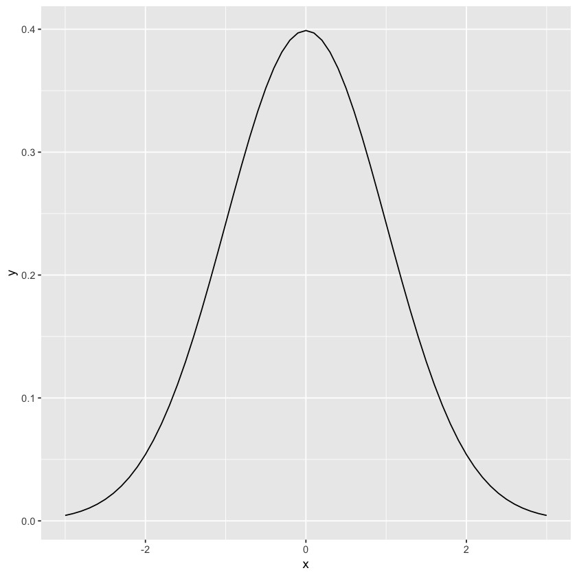

```r
# plots the standard normal distribution for the interval –3 to +3
library(ggplot2)

x <- seq(-3, +3, 0.1)
dens <- data.frame(x = x, y = dnorm(x))

ggplot(dens, aes(x, y)) + geom_line()
```

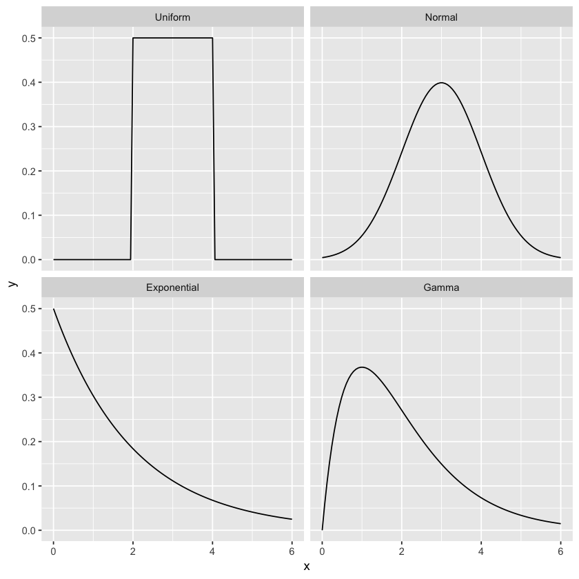

```r
x <- seq(from = 0, to = 6, length.out = 100) # Define the density domains
ylim <- c(0, 0.6)

# Make a data.frame with densities of several distributions
df <- rbind(
  data.frame(x = x, dist_name = "Uniform"    , y = dunif(x, min   = 2, max = 4)),
  data.frame(x = x, dist_name = "Normal"     , y = dnorm(x, mean  = 3, sd = 1)),
  data.frame(x = x, dist_name = "Exponential", y = dexp(x, rate  = 1 / 2)),
  data.frame(x = x, dist_name = "Gamma"      , y = dgamma(x, shape = 2, rate = 1)) )

# Make a line plot like before, but use facet_wrap to create the grid
ggplot(data = df, aes(x = x, y = y)) +
  geom_line() +
  facet_wrap(~dist_name)   # facet and wrap by the variable dist_name
```

How to create a density plot with shaded area at the Q-th quantile:

- We create the plot by first plotting the density and then creating a shaded region with the geom_ribbon function from ggplot2.

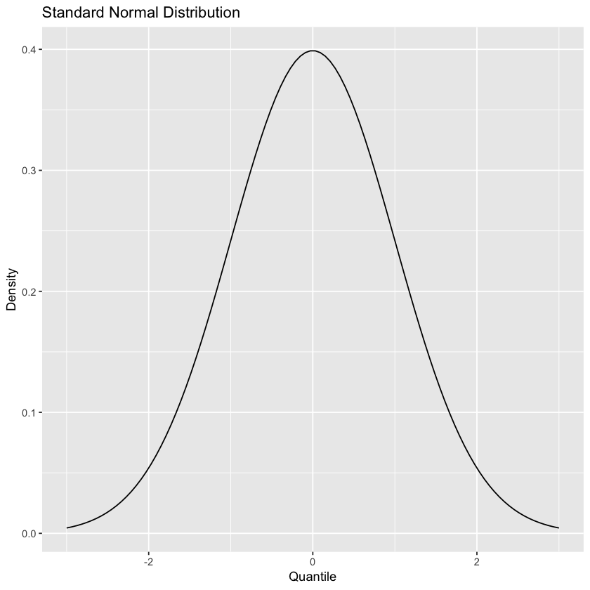

```r
x <- seq(from = -3, to = 3, length.out = 100)
df <- data.frame(x = x, y = dnorm(x, mean = 0, sd = 1))

p <- ggplot(df, aes(x, y)) +
  geom_line() +
  labs(
    title = "Standard Normal Distribution",
    y = "Density",
    x = "Quantile"
  )
p
```

- Next, we define the region of interest by calculating the x value for the quantiles we’re interested in.  
  Finally, we use a geom_ribbon to add a subset of our original data as a colored region.

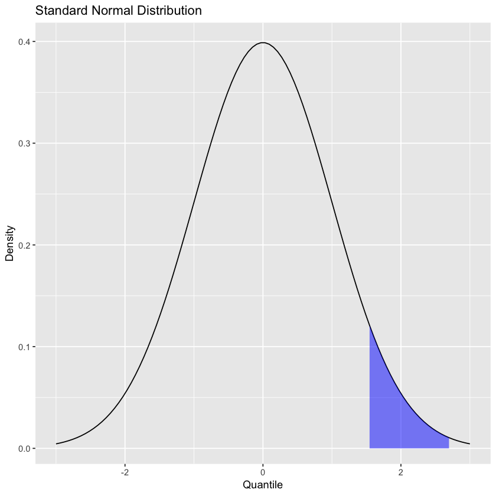

```r
q75 <- quantile(df$x, .75)
q95 <- quantile(df$x, .95)

p +
  geom_ribbon(
    data = subset(df, x > q75 & x < q95),
    aes(ymax = y),
    ymin = 0,
    fill = "blue",
    colour = NA,
    alpha = 0.5
  )
```

## General Statistics

### Null Hypotheses, Alternative Hypotheses, and p-Values

One hypothesis, called the null hypothesis $H_0$, is that nothing happened: the mean was unchanged; the treatment had no effect; you got the expected answer; the model did not improve; and so forth.

The other hypothesis, called the alternative hypothesis $H_A$, is that something happened: the mean rose; the treatment improved the patients’ health; you got an unexpected answer; the model fit better; and so forth.

```
note: There is always a "naive" methods to remember the Null and Alternative hypothesis settings.
Null Hypothesis:        Always equals to something
Alternative Hypothesis: Always diff or not equal something
```

We want to determine which hypothesis is more likely in light of the data:

1. To begin, we assume that the null hypothesis is true.
2. We calculate a test statistic. It could be something simple, such as the mean of the sample, or it could be quite complex. The critical requirement is that we must know the statistic’s distribution. We might know the distribution of the sample mean, for example, by invoking the Central Limit Theorem.
3. From the statistic and its distribution we can calculate a p-value, the probability of a test statistic value as extreme or more extreme than the one we observed, while assuming that the null hypothesis is true.
4. If the p-value is too small, we have strong evidence against the null hypothesis. This is called rejecting the null hypothesis.
5. If the p-value is not small, then we have no such evidence. This is called failing to reject the null hypothesis.

There is one necessary decision here: When is a p-value “too small”?

*This is a compact way of saying:*

1. *The null hypothesis is that the variables are independent.*
2. *The alternative hypothesis is that the variables are not independent.*
3. *For $α = 0.05$, if $p < 0.05$ then we reject the null hypothesis, giving strong evidence that the variables are not independent; if $p > 0.05$, we accept the null hypothesis.*
4. *You are free to choose your own $α$, of course, in which case your decision to reject or fail to reject might be different.*

### Testing Categorical Variables for Independence

##### Problem

You have two categorical variables that are represented by factors. You want to test them for independence using the chi-squared test.

#### Solution

```r
# Create some synthetic data
set.seed(42)
initial <- factor(sample(c("Yes", "No", "Maybe"), 100, replace = TRUE))
outcome <- factor(sample(c("Pass", "Fail"), 100, replace = TRUE))
```

```r
?table
```

```r
table(initial)
```

```
initial
Maybe    No   Yes
   21    39    40
```

```r
table(outcome)
```

```
outcome
Fail Pass
  56   44
```

```r
summary(table(initial, outcome))
```

```
Number of cases in table: 100
Number of factors: 2
Test for independence of all factors:
	Chisq = 0.030029, df = 2, p-value = 0.9851
```

The output includes a p-value. Conventionally, a p-value of less than 0.05 indicates that the variables are likely not independent, whereas a p-value exceeding 0.05 fails to provide any such evidence.

The large p-value indicates that the two factors, initial and outcome, are probably independent. Practically speaking, we conclude there is no connection between the variables. This makes sense, as this example data was created by simply drawing random data using the sample function in the prior recipe.

As we proceed we will see how to create tests - given the data. In this case we would use the `chisq.test`

### Quantiles

#### Calculating Quantiles (and Quartiles) of a Dataset

##### Problem

Given a fraction $f$, you want to know the corresponding quantile of your data. That is, you seek the observation $x$ such that the fraction of observations below $x$ is $f$.

#### Solution

Use the `quantile` function. The second argument is the function

```r
vec <- runif(1000)
quantile(vec, .05)
```

**5%:** 0.0445380330667831

```r
quantile(vec, c(.05, .95))
```

**5%**

0.0445380330667831

**95%**

0.948434168193489

#### Inverting a Quantile

##### Problem

Given an observation $x$ from your data, you want to know its corresponding quantile. That is, you want to know what fraction of the data is less than $x$.

##### Solution

ssuming your data is in a vector vec, compare the data against the observation and then use mean to compute the relative frequency of values less than x—say, 1.6 as per this example.

```r
mean(vec < 1.6)
```

1

#### Testing for Normality

##### Problem

A statistical test to determine whether your data sample is from a normally distributed population.  
This will serve as an introduction to further tests we will be performing for normality.

##### Solution

Use the shapiro.test function:

```
shapiro.test(x)
```

The output includes a p-value. Conventionally, $p < 0.05$ indicates that the population is likely not normally distributed, whereas $p > 0.05$ provides no such evidence.

```
shapiro.test(x)
#>
#>  Shapiro-Wilk normality test
#>
#> data:  x
#> W = 1, p-value = 0.4
```

The large p-value suggests the underlying population could be normally distributed. The next example reports a very small p-value for y, so it is unlikely that this sample came from a normal population:

```
shapiro.test(y)
#>
#>  Shapiro-Wilk normality test
#>
#> data:  y
#> W = 0.7, p-value = 7e-13
```

We have highlighted the Shapiro–Wilk test because it is a standard R function. You can also install the package nortest, which is dedicated entirely to tests for normality. This package includes:

- Anderson–Darling test (ad.test)
- Cramer–von Mises test (cvm.test)
- Lilliefors test (lillie.test)
- Pearson chi-squared test for the composite hypothesis of normality (pearson.test)
- Shapiro–Francia test (sf.test)

The problem with all these tests is their null hypothesis:

they all assume that the population is normally distributed until proven otherwise. As a result, the population must be decidedly non-normal before the test reports a small p-value and you can reject that null hypothesis. That makes the tests quite conservative, tending to err on the side of normality.